# Week #1 Summary

## What we did:

1. Installed GitHub and introduced how to use a GitHub repository
2. Reviewed the non-parametric bootstrap
3. Worked through several exercises to demonstrate the use of the bootstrap and cases where the bootstrap fails

Basic idea behind the bootstrap:

We will get into more details in the next few chapters of Efron and Tibshirani, but the basic idea behind the bootstrap is that we can generate a statistical distribution for an estimator by sampling with replacement from the original data. (Ideally, you could generate this same distribution by simply re-doing your experiment [or collecting another random sample from the population of interest] many many times. Each new experiment would yield another estimate for the parameter of interest, and the distribution of these estimates would give you information about the bias and variance of the estimator.)

Throughout our discussion of bootstrap, we will adopt Efron & Tibshirani's notation. Our original data will be called \( x \) and bootstrapped datasets will be denoted \( x^{*} \). The parameter of interest will be called \( \theta \), and its estimation using the actual empirical (original) data will be called \( \hat{\theta} \). We can use each bootstrapped dataset \( x^{*} \) to calculate the bootstrapped estimate \( \hat{\theta^{*}} \). Generally speaking, and in a way that will become clear over the next few weeks, bootstrapping 'works' if the distribution of the bootstrapped estimator relative to the original empirical estimate converges to that of the empirical estimate relative to the true population value

\[ \hat{\theta^{*}}-\hat{\theta} \rightarrow \hat{\theta}-\theta \]

In the Week #1 seminar, we worked through three case studies to demonstrate both bootstrap 'working' and bootstrap 'failing'.

## Case Study #1: When bootstrap works

To demonstrate bootstrap working, we did two things:

1. We drew 100 samples from

\[ X \sim N(\mu=1,\sigma=3) \]

and calculated the sample mean of each. This simulates doing the experiment 100 times (something we can rarely do in practice).

1. We drew 1 sample from

\[ X \sim N(\mu=1,\sigma=3) \]

and then created 99 bootstrapped replicates of the original dataset (so the original plus the 99 bootstrapped samples is equivalent to the 100 samples from the true underlying population). We then calculated the sample mean of each of these samples (one original+99 bootstrapped).

To the extent to which these two distributions are approximately the same, and become more similar as the sample size increases, is a measure of whether bootstrapping has 'worked'.

I show some example code below (slightly edited for formatting), in part to demonstrate some of the ways in which different people write code for the very same exercise (even when, in this case, the exercise is quite straightforward). [NB: Most people drew 100 bootstrapped datasets, as opposed to 99 bootstrapped datasets to add to the original empirical dataset. In practice, I don't think it matters, but we can certainly discuss this…]

From Jon Borrelli:

Exercise 1 - Normal

Drawing 1000 samples of 100 randomly drawn values from a normal

```r
opts_chunk$set(cache = T)
samples <- matrix(nrow = 1000, ncol = 100)
for (i in 1:1000) {
    samples[i, ] <- rnorm(100, 1, 3)
}

meansSAMPLE <- rowMeans(samples)
```

Bootstrapping

```r
norm1 <- rnorm(100, 1, 3)
boot <- matrix(nrow = 1000, ncol = 100)
for (i in 1:1000) {
    boot[i, ] <- sample(norm1, 100, replace = T)
}

meansBOOT <- rowMeans(boot)
```

Plot the histograms (blue=sample result, red=boostrapping result)

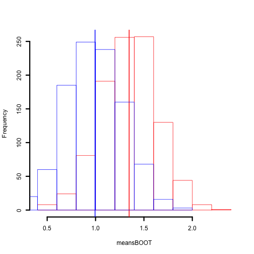

```r
hist(meansBOOT, border = "red", main = NA, lwd = 3)
abline(v = mean(meansBOOT), col = "red", lwd = 2)
hist(meansSAMPLE, border = "blue", add = T, main = NA, lwd = 3)
abline(v = mean(meansSAMPLE), col = "blue", lwd = 2)
```

From Ben Weinstein:

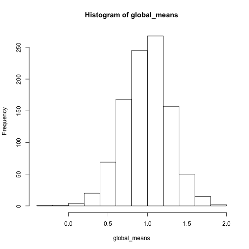

```r
# Seminar 1 - Bootstrap test
require(ggplot2)
# Repeat the experiment 1000 times
global_means <- replicate(1000, mean(rnorm(100, mean = 1, sd = 3)))  #HJL: Changed mean to 1
hist(global_means)
```

```
## stat_bin: binwidth defaulted to range/30. Use 'binwidth = x' to adjust this.
## stat_bin: binwidth defaulted to range/30. Use 'binwidth = x' to adjust this.
```

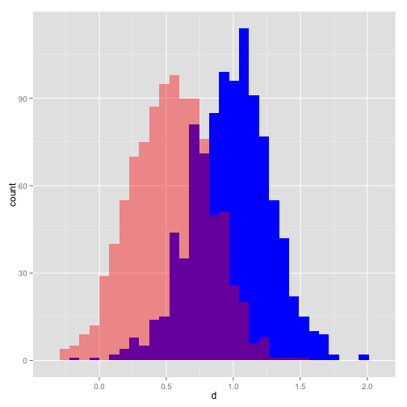

```r
# make a dataframe
draws <- data.frame(d = global_means)

# 1000 bootstrap replicates of 1 experiment
j <- rnorm(100, mean = 1, sd = 3)  #HJL: Changed mean to 1
b <- replicate(1000, mean(sample(j, replace = TRUE)))
boots <- data.frame(b = b)

# compare histograms
ggplot() + geom_histogram(data = draws, aes(x = d), fill = "blue") + geom_histogram(data = boots,
    aes(x = b), fill = "red", alpha = 0.4)
```

If you run this several times, you'll notice that the two histograms are not always right on top of one another. As you make the sample sizes (not the number of bootstraps, but the size of the original dataset) bigger, there is closer (and more robust) correspondence between the two histograms. However, even when the bootstrap distribution is off (in the sense of shifted from the original), its variance is usually pretty close. This is good news, since we are often interested in using the standard deviation of the bootstrapped estimates to estimated an estimates standard error. This is a good illustration of the fact that bootstrap gets better as sample sizes get better (and special caution should be applied when bootstrapping small datasets).

## Case Study #2: When bootstrap fails because of the sample statistic

One of the times when bootstrap is known to fail is when you are interested in the extremes of a distribution. To demonstrate this, we worked through a classic example is which the bootstrap fails:

\[ X \sim Unif(0,5) \]

with \( \theta = max(X) \) (a.k.a. \( X_{(n)} \)).

From Jon Borrelli:

Exercise 2 - Uniform

```r
samples2 <- matrix(nrow = 1000, ncol = 1000)
for (i in 1:1000) {
    samples2[i, ] <- runif(1000, 0, 5)
}

maxSAMPLE <- apply(samples2, 1, max)
```

Bootstrapping

```r
unifsampl <- runif(1000, 0, 5)
boot2 <- matrix(nrow = 1000, ncol = 1000)
for (i in 1:1000) {
    boot2[i, ] <- sample(unifsampl, 1000, replace = T)
}

maxBOOT <- apply(boot2, 1, max)
```

Plot the histograms

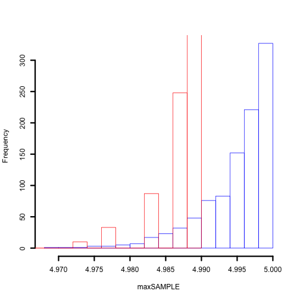

```r
hist(maxSAMPLE, border = "blue", main = NA, lwd = 3)
hist(maxBOOT, border = "red", add = T, lwd = 3)
```

Probability of getting the largest value in original in the bootstrapped sample is

\[ \LARGE{ 1 - (1 - \frac{1}{n})^n } \]

Therefore, bootstrap is not very good with **extreme** values.

From Ben Weinstein:

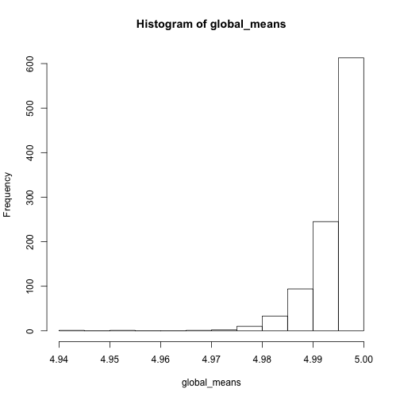

```r
# Seminar 1 - Bootstrap test
require(ggplot2)
# Repeat the experiment 1000 times
global_means <- replicate(1000, max(runif(1000, 0, 5)))
hist(global_means)
```

```
## stat_bin: binwidth defaulted to range/30. Use 'binwidth = x' to adjust this.
## stat_bin: binwidth defaulted to range/30. Use 'binwidth = x' to adjust this.
```

[figure not shown]

```r
# make a dataframe
draws <- data.frame(d = global_means)

# 1000 bootstrap replicates of 1 experiment
j <- runif(1000, 0, 5)
b <- replicate(1000, max(sample(j, replace = TRUE)))
boots <- data.frame(b = b)

# compare histograms
ggplot() + geom_histogram(data = draws, aes(x = d), fill = "blue") + geom_histogram(data = boots,
    aes(x = b), fill = "red", alpha = 0.4)
```

[figure not shown]

```r
ggplot() + geom_density(data = draws, aes(x = d), fill = "blue") + geom_density(data = boots,
    aes(x = b), fill = "red", alpha = 0.4)
```

## Case Study #3: When bootstrap fails because the distribution has ill defined moments

One of the other times when bootstrap is known to fail is when you have a distribution will is poorly behaved, which is to say that it has moments that are ill defined. We demonstrated this with a classic porrly-behaved distribution, the Cauchy distribution (which has an undefined mean and variance)[The parameters are fairly arbitrary here]:

\[ X \sim Cauchy(1,2) \]

with \( \theta = var(X) \).

I've included Jon and Ben's code below, but because the Cauchy is so pathalogical, the histograms aren't much use. Its better to just play around with the code to get a sense for what's going on.

From Jon Borrelli:

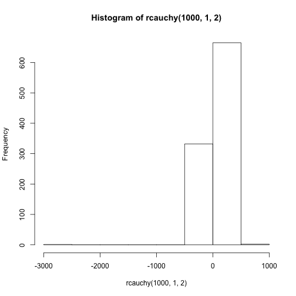

```r
hist(rcauchy(1000, 1, 2))
```

```r
samples3 <- matrix(nrow = 1000, ncol = 1000)
for (i in 1:1000) {
    samples3[i, ] <- rcauchy(1000, 1, 2)
}

varSAMPLE <- apply(samples3, 1, var)
```

Bootstrapping

```r
cauchysampl <- rcauchy(1000, 1, 2)
boot3 <- matrix(nrow = 1000, ncol = 1000)
for (i in 1:1000) {
    boot3[i, ] <- sample(cauchysampl, 1000, replace = T)
}

varBOOT <- apply(boot3, 1, var)
```

Plot the histograms

[figure not shown]

```r
hist(varSAMPLE, border = "blue", main = NA, lwd = 3, freq = F)
hist(varBOOT, border = "red", lwd = 3, add = T, freq = F)
```

## Additional Reading:

For more information about Week #1's topics, a few helpful references are:

Athreya, K.B. 1987. Bootstrap of the mean in the infinite variance case. The Annals of Statistics 15(2): 724-731.

Bickel, P.J., and D. A. Freedman. 1981. Some asymptotic theory for the bootstrap. The Annals of Statistics 9(6): 1196-1217.

# Week #2 Summary

## What we did:

1. We discussed uses for **R Markdown**. This is a general-purpose package which will generate .Rmd, .md and .html files. R Markdown is useful because it can write files which may variously contain and run .r script within the document, and will generate any associated figures, etc.

   > > (**NOTE:** If you have not yet, please install the knitr package (which will also install the markdown package)
2. We discussed **LaTeX**, which is a typsetting program especially powerful for writing mathematical formulas. Several LaTeX texts were posted on Blackboard, and are useful for both general introduction to the program and as a reference for LaTeX coding.
3. We discussed a few key points from the reading (Ch. 3-8 in Efron and Tibshirani).
4. We worked on a bootstrapping problem in pairs during class. Each group then posted their R Markdown files containing their answers to the problem on GitHub. Lastly, we discussed which of the 3 approaches we tried for bootstrapping is the best method.

## A few R Markdown Basics

- To write code that will run as embedded within R Markdown:  
  Type:

  ```
  {r}
  summary(cars)
  ```

If you wanted to have the code show, but not run, leave off the '{r}'.

(Here I have borrowed some of the default text that comes with a new R Markdown project)

## A few LaTeX formulas

- LaTex's strongest point is its ability to write mathematical formulas clearly.
- LaTex code will generally contain a backslash to indicate what needs to use LaTex.
> - A double dollar sign surrounding LaTex code instructs R to write the formula on a separate line.
> - A single surrounding LaTex code instructs R to write the formula within a line of text.

Examples of LaTex writing:  
As a separate line of code, write as follows (although don't separate dollar signs with a space):  
$ $  
\pi=3.14  
$ $ **… will output:**  
\[ \pi=3.14 \]

Within a single line of code, separate with a single dollar sign (again, leave out spaces between the dollar signs and within the LaTex code):

> blah blah $ \ pi=3.14 $ blah blah …**will output**… blah blah \( \pi=3.14 \) blah blah.

Here are a few examples of LaTex coding for other equations. Again, leave out spaces to have the code compile.

- Superscript: \( X^{3} \) is written as $ X<sup>{3}</sup> $
- Subscript: \( X_{3} \) is written as $ X_{3} $
- Fractions: \( \frac{2}{7} \) is written as $ \ frac{2}{7} $
- Greek letters: \( \Omega \) and \( \omega \) are written as $ \Omega $ and $ \omega $
- Square roots: \( \sqrt{5} \) is written as $ \sqrt{5} $
- Hats: \( \hat{alpha} \) is written as $ \hat{alpha} $
- Limits: \( \lim_{n\rightarrow5} \) is written as $ \lim_{n\rightarrow5} $
- Integrals: \( \int_{0}^{10} \) is written as $ \int_{0}<sup>{10}</sup> $; note that LaTex is smart enough that the order you enter the numbers for your limits doesn't matter.
- Sum: \( \sum{(x:y)} \) is written $ \sum{(x:y)} $
- Approx.: \( \sim3 \) is $ \sim3 $; \( \approx3 \) is $ \approx3 $

Putting it all together to write a complex expression example:  
\[ \lim_{\epsilon\rightarrow0_{+}} \frac{\int_{\alpha_{i}}^{\alpha_{i+\epsilon}} \sqrt{1+(x-\mu)^2}dx} {\phi(\epsilon)} \]  
**… is written as:**  
$ $  
\lim_ {\epsilon\rightarrow0{+}}  
\frac{\int {\alpha_ {i}} ^ {\alpha_ {i+\epsilon}}  
\sqrt { 1 + (x- \ mu) <sup>2</sup> } dx}  
{ \phi (\epsilon) } dx $ $

## Discussing a few key points from Ch. 3-8 in E+T

What's the difference between a **census** and a **sample**?

> > A census observes the entire population, whereas a sample looks at only a representative part of the entire population. With a census, you can just run mathematical calculations to say something descriptive about the population (ie., mean, mode, etc.). In contrast, a sample must use statistics with the data, because the information you have represents part of the larger population whole, which you can use to infer larger, population-descriptive relationships.

What's the difference between a **parameter** and a **statistic**?

> > A parameter belongs to the distribution of a population- it is a function of the distribution *F*. A statistic is any metric calculated from your data, and is a function of *x* as drawn from *F*. Statistics are used to estimate parameters of interest for the population.

What is the **plug-in principle**?

> > This is the core of E+T's book, and of bootstrapping. The plug-in principle says that although you would like to know a whole-population parameter \( \Theta\ \) = t(*F*), you probably can't sample the whole population. Therefore, take a random sample of that population to estimate \( \hat{\Theta} \), which will be applied to your data/the emperical distribution (= t(\( \hat{F} \))).

> > Note that your unbiased estimate for \( \hat{\Theta} \) is the best estimate that you can get for \( \Theta \), as you are assuming that your data (the emperical distribution) is a good representitive of the unknown distribution for the entire population.

> > This doesn't mean that your estimate for \( \Theta \) is *good*, it's just the best you can do given your data!

Note that E+T mostly focus on non-parametric bootstraps. A parametric distribution/bootstrap should be used if your data is so sparse that you would get more options for fitting a \( \hat{\Theta} \) if you assumed a distribution from which to draw. Additionally, if you have *a priori* knowledge of the population from which you draw your sample and know it fits a particular distribution, a parameteric bootstrap can be used.

The ultimate goal of bootstrapping is to try to recreate the process that generated the data. The method used for bootstrapping should reflect this, and take into consideration the hypothesis that is being tested.

## In-class problem

We were given data on bird clutch size for a variety of species.  
1. What's the best distribution for clutch size?  
2. What's the mean clutch size, using three nonparametric bootstrap techniques:

> A. Sample with replacement from **species** (irregardless of higher taxonomy)  
> B. Sample with replacement from **family**, then sample the species from that list with replacement, bootstrapping the species samples.  
> C. Bootstrap **across all levels** by sampling with replacement from family, then sampling within this for genera, and then within this for species (hierarchical sampling).

### Here is the code, as run by Sarah Supp and Emily Rollinson.

First, we read in the data on Clutch Size.

```r
library(ggplot2)
library(MASS)
require(RCurl)
options(RCurlOptions = list(cainfo = system.file("CurlSSL", "cacert.pem", package = "RCurl")))
url <- getURL("https://raw.githubusercontent.com/PermuteSeminar/PermuteSeminar-2014/master/ClutchSize.csv")
clutch <- read.csv(text = url, header = T)

print(nrow(clutch))
```

```
## [1] 2392
```

**1. What is the best distribution for the clutch size data?**

The data are continuous, long right tail

```
## stat_bin: binwidth defaulted to range/30. Use 'binwidth = x' to adjust this.
```

[figure not shown]

```r
ggplot(clutch, aes(Clutch_size)) + geom_histogram(col = "white") + theme_classic() +
    theme(text = element_text(size = 20))
```

```r
fitdistr(clutch$Clutch_size, densfun = "lognormal")
```

```
##    meanlog     sdlog
##   1.111122   0.502051
##  (0.010265) (0.007259)
```

```r
avg = mean(clutch$Clutch_size)
med = median(clutch$Clutch_size)
stdev = sd(clutch$Clutch_size)
```

**2. What is the statistic mean? Sample with replacement from:**  
**a) species**

```r
print(avg)
```

```
## [1] 3.448
```

```r
n = nrow(clutch)

est = NULL
for (i in 1:1000) {
    boot = sample(clutch$Clutch_size, n, replace = TRUE)
    mean.1 = mean(boot)
    est = append(est, mean.1)
}

mean(est)
```

```
## [1] 3.448
```

**b) family**

```r
f = length(unique(clutch$Family))

est2 = NULL
for (i in 1:1000) {
    fam = sample(clutch$Family, f, replace = TRUE)
    subdat = clutch[which(clutch$Family %in% fam), ]
    boot = sample(subdat$Clutch_size, n, replace = TRUE)
    mean.2 = mean(boot)
    est2 = append(est2, mean.2)
}

mean(est2)
```

```
## [1] 3.468
```

**c) bootstrap at all levels - sample with replacement for families, we used the total number of unique families. Within those families, count the number of unique genera, and sample from the genera. Within those genera, sample from the species, such that n = the length of the original dataset**

```r
f = length(unique(clutch$Family))

est3 = NULL
for (i in 1:1000) {
    fam = sample(clutch$Family, f, replace = TRUE)
    subdat = clutch[which(clutch$Family %in% fam), ]
    g = length(unique(subdat$Genus_name))  #this is not exactly what Heather was saying
    gen = sample(subdat$Genus_name, g, replace = TRUE)
    subdat2 = subdat[which(subdat$Genus_name %in% gen), ]
    boot = sample(subdat2$Clutch_size, n, replace = TRUE)
    mean.3 = mean(boot)
    est3 = append(est3, mean.3)
}

mean(est3)
```

```
## [1] 3.458
```

**Plot the data as histograms. The first method matches the mean of the original data and has lower variance. The second two methods are similar (in the way that we implemented them) but have wider variance.**

```
## stat_bin: binwidth defaulted to range/30. Use 'binwidth = x' to adjust this.
## stat_bin: binwidth defaulted to range/30. Use 'binwidth = x' to adjust this.
## stat_bin: binwidth defaulted to range/30. Use 'binwidth = x' to adjust this.
```

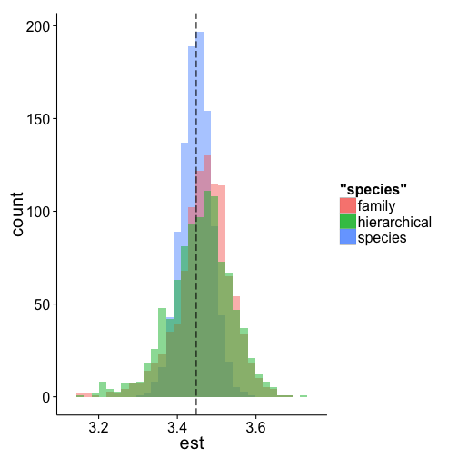

```r
bootdata = data.frame(est, est2, est3)

ggplot(bootdata, aes(est, fill = "species")) + geom_histogram(alpha = 0.5) +
    theme_classic() + theme(text = element_text(size = 20)) + geom_histogram(aes(est2,
    fill = "family"), alpha = 0.5) + geom_histogram(aes(est3, fill = "hierarchical"),
    alpha = 0.5) + geom_vline(data = clutch, aes(xintercept = mean(Clutch_size)),
    linetype = "longdash")
```

The population mean is 3.448. The data bootstrapped by species is 3.4476, by family is 3.4684, and by family hierarchically is 3.4584.

## Assigned Readings:

Downes, M. Short Math Guide for LATEX. version 1.09. http://www.ams.org/tex/short-math-guide.html, 2002

## Additional Reading:

Efron, B., and R. Tibshirani. 1986. Bootstrap methods for standard errors, confidence intervals, and other measures of statistical accuracy. Statistical science:54–75.

# Week #4 Summary

**How to read files (such as .csv) from Github on Rmarkdown documents:**

Install the RCurl package

> Use getURL() function:

```r
require(RCurl)
```

I was experiencing a certificate error with getURL(). The following code seems to fix the problem in case you experience the same:

```r
options(RCurlOptions = list(cainfo = system.file("CurlSSL", "cacert.pem", package = "RCurl")))

raw <- getURL("https://raw.githubusercontent.com/PermuteSeminar/PermuteSeminar-2014/master/Week-2/ClutchSize.csv")
clutch <- read.csv(text = raw)  #make sure to upload RAW data file
head(clutch)
```

```
##   Family Genus_name             Species_name Clutch_size
## 1      3   Dromaius Dromaius novaehollandiae        8.98
## 2      4    Apteryx        Apteryx australis        2.00
## 3      4    Apteryx          Apteryx haastii        1.00
## 4      4    Apteryx           Apteryx owenii        1.00
## 5      6    Ortalis           Ortalis vetula        2.88
## 6      7   Alectura         Alectura lathami       14.78
##              English_name
## 1                     Emu
## 2              Brown Kiwi
## 3      Great Spotted Kiwi
## 4     Little Spotted Kiwi
## 5        Plain Chachalaca
## 6 Australian Brush-turkey
```

# Lecture Notes

## adapted from Emily Rollinsion

> For this week, we read Chapter 8 in Efron and Tibshirani, and notes on bootstrapping dependent data (Steigerwald; posted to GitHub and on Blackboard). This chapter provides an overview of bootstrapping procedues for more complicated data structures than the one-sample model, such as time-dependent data or otherwise non-IID data.

## In-class discussion:

The goal of the bootstrap algorithm is to estimate the probability distribution that underlies our data. We can use our empirical distribution in lieu of the full distribution to understand the distribution of statisics of interest (mean, variance, etc.).

Bootstraps are often used to estimate standard errors. We select \( B \) independent bootstrap samples, calculate our test statistic using the bootstrap samples, and use the standard deviation of the \( B \) replications as an estimate of the standard error of the unknown distribution \( F \) that underlies our empirical data. Resampled populations should equal the number of orginal samples. *'s are used to indicate resampled items.

This works for both a single unknown distribution (see Figure 8.1 in E&T) or a more complicated underlying process or a whole set of unknown distributions (see Figure 8.3 in E&T). We could easily imagine some biological measure influenced by many processes (i.e., many underlying and unknown statistical distributions).

## Today's example:

We used the data from Leutenizing hormone example in Efron and Tibshirani (Ch. 8). This formed a time series with some temporal stucture. the whole distirbution may be normal.

We will model this using an autoregressive model of period 1. \[ AR(1): z_{t} = \beta_{z_{t-1}} + \epsilon_{t} \]

> where \( z_{t} \) has an expectation 0 and \( \beta \) is an unknown parameter, a number between -1 and 1.

## In class Excercises

**Use dataset from book:**

## **1. Estimate \( \hat{\beta} \) **

Solution: Adapted from Jon Borrelli

Load Required Packages

```r
require(RCurl)
require(ggplot2)
```

Load Dataset:

```r
options(RCurlOptions = list(cainfo = system.file("CurlSSL", "cacert.pem", package = "RCurl")))

raw <- getURL("https://raw.githubusercontent.com/PermuteSeminar/PermuteSeminar-2014/master/Week-4/hormone_data.csv")
hormone <- read.csv(text = raw)
head(hormone)
```

```
##   period level
## 1      1   2.4
## 2      2   2.4
## 3      3   2.4
## 4      4   2.2
## 5      5   2.1
## 6      6   1.5
```

Calculate \( z_t \) for each data point: \( z_t = y_t-\mu \)

```r
z.t <- hormone$level - mean(hormone$level)
z.t
```

```
##  [1]  0.0  0.0  0.0 -0.2 -0.3 -0.9 -0.1 -0.1  0.1 -0.4 -0.5 -0.7 -0.2 -0.6
## [15]  0.8  0.8  0.3 -0.2 -0.2 -0.5 -0.5 -0.6  0.3  0.6 -0.1 -0.4 -0.4  0.5
## [29]  0.5  0.3  0.3 -0.1  0.2  0.0 -0.6 -0.7 -0.9 -1.0 -0.3  0.9  1.1  1.1
## [43]  0.7  0.2 -0.3  1.0  0.6  0.5
```

Calculate residual squared errors for each value of \( z_t \) and all possible values of \( b \). \[ RSE(b) = \sum_{t-U}^{V}(z_t - bz_{t-1})^2 \]

Generate a function that does this calculation over these values and picks out the best value for \( b \) that minimizes RSE.

```r
rse <- function(zt, b) {
    est.b <- c()
    for (i in 1:length(b)) {
        res <- c()
        for (j in 2:length(zt)) {
            res[j - 1] <- (zt[j] - b[i] * zt[j - 1])^2  #RSE equation
        }
        est.b[i] <- sum(res)
    }
    bhat <- b[which.min(est.b)]
    return(bhat)
}
```

Run the function and get \( \hat{\beta} \)

```r
b <- seq(-1, 1, 0.001)  #generates a sequence of possible values for b
bhat <- rse(z.t, b)  #runs the function
bhat
```

```
## [1] 0.586
```

**So our estimate of \( \hat{\beta} \) is 0.586**

## 2a. See how good our estimate of \( \hat{\beta} \) is by figuring out confidence intervals (Standard error) of \( \beta \) by bootstrapping methods

We need to estimate \( P = (\beta,F) \) from the data.

Since we have \( \hat{\beta} \) we can use it to estimate \( F \) distribution of the distubances and calculate \( \epsilon_{t} = z_{t} - \beta z_{t-1} \) for every \( t \)

```r
eps <- c()  #collects all the calculate values of epsilon

for (i in 1:length(z.t)) {
    eps[i] <- z.t[i] - bhat * z.t[i - 1]
}
```

A histrogram of the approximate disturbances. It is not a normal distribution. The Mean = 0.0062

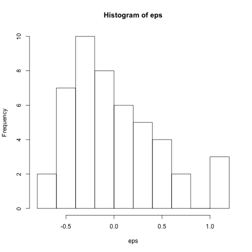

```r
hist(eps)
```

Resample \( F \) Distribtuion of values of \( \epsilon \) with replacement:

```r
boot.eps <- matrix(nrow = 200, ncol = 47)
for (rep in 1:200) {
    boot.eps[rep, ] <- sample(eps[2:48], 47, replace = T)
}
```

Generate bootstrap values for time series \( z_{t}* \):

```r
z.tmat <- matrix(nrow = 200, ncol = 48)
z.tmat[, 1] <- z.t[1]
for (rep in 1:200) {
    for (cols in 1:47) {
        z.tmat[rep, cols + 1] <- bhat * z.tmat[rep, cols] + boot.eps[rep, cols]
    }
}
```

Generate bootsrap replications of \( \hat{\beta} \)

```r
b.test <- seq(0, 1, 0.001)
bhatboot <- apply(z.tmat, 1, rse, b = b.test)  #Uses RSE function created above
```

Histogram of the generated \( \hat{\beta} \) values. The mean = 0.5793

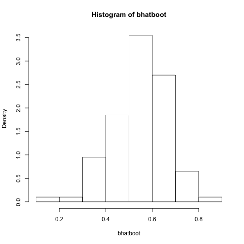

```r
hist(bhatboot, freq = F)
```

## 2b. Use a moving blocks bootstrap

```r
head(hormone)
```

```
##   period level
## 1      1   2.4
## 2      2   2.4
## 3      3   2.4
## 4      4   2.2
## 5      5   2.1
## 6      6   1.5
```

```r
block <- matrix(nrow = 3, ncol = 46)
for (i in 1:46) {
    block[1, i] <- z.t[i]
    block[2, i] <- z.t[i + 1]
    block[3, i] <- z.t[i + 2]
}

boot.block <- matrix(nrow = 500, ncol = 48)
for (i in 1:500) {
    bcol <- sample(1:46, 16, replace = T)
    boot.block[i, ] <- as.vector(block[, bcol])
}

b.test <- seq(0, 1, 0.001)

bhatboot2 <- apply(boot.block, 1, rse, b = b.test)
```

Histogram of estimates generatated from the Moving Blocks BootStrap with mean of 0.3925

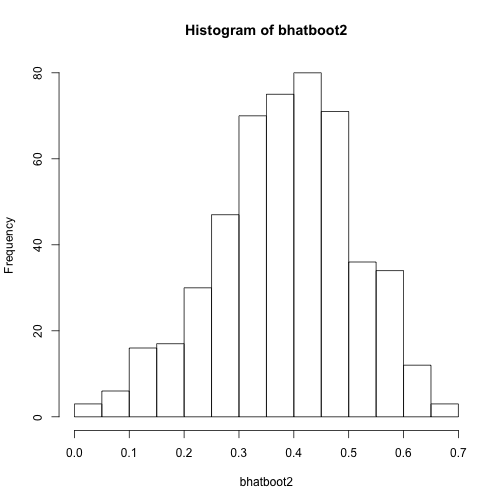

```r
hist(bhatboot2)
```

## Assigned Reading:

Efron, B., and R.J. Tibshirani 1994. An introduction to the bootstrap (Vol. 57). CRC press. Chapter8

## Additional reading:

More on the moving block boostrap:  
Lahiri, S. 1993. On the moving block bootstrap under long range dependence. Statistics & Probability Letters 18(5):4.5-413.

# Week #5 Summary

Randomization is a method for formulating and testing a null hypothesis of “randomness” given a particular set of data. In this conception, our alternative hypothesis (i.e., that there *is* some effect, difference, correlation, etc.) corresponds to a certain level of organization or structure in our data. If this is the case, then shuffling the order of our measurements (randomizing) will destroy that structure and change the value of our test statistic. If, on the other hand, the null hypothesis is true, and ther is *not* any structure, then reshuffling the data won't produce much change in the chosen test statistic.

A randomization test simply reshuffles the data and calculates the test statistic many times, counting what proportion of test statistics are at least as extreme as the one calculated from the original data. The shuffling may be a simple reordering, or it may attempt to preserve certain features of the original data or the process that generated it. One example mentioned in class was phylogenetic trees: if you just shuffle the order of species, OF COURSE you're going to get a significant result, since the process that created the species (evolution) is branching and autocorrelated. To get meaningful significance levels, you would need to come up with a randomization scheme that preserves some of these characteristics.

Design of a randomization scheme for taxonomic relationships under the assumption of Intelligent Design is left as an exercise for the reader.

## Jackal jaws

To show the idea of randomization in action, the following is a re-created example of the jackal jaws from the reading.

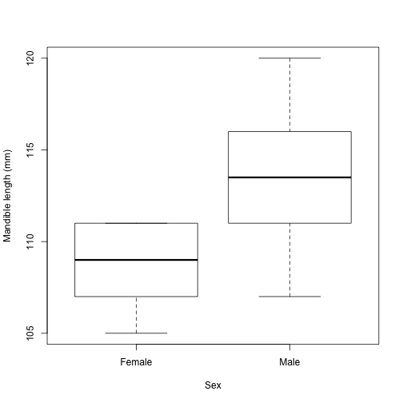

```r
jackals <- data.frame(mandible = c(120, 107, 110, 116, 114, 111, 113, 117, 114,
    112, 110, 111, 107, 108, 110, 105, 107, 106, 111, 111), sex = rep(c("Male",
    "Female"), each = 10))
boxplot(mandible ~ sex, jackals, xlab = "Sex", ylab = "Mandible length (mm)")
```

So it definitely appears like males have larger mandibles. But how sure are we? For a standard statistical test of the difference in means, we can just use R's `lm()` function (this is equivalent to doing a two-sample T-test, and gives us the same p-value).

```r
mod <- lm(mandible ~ sex, jackals)
summary(mod)
```

```
##
## Call:
## lm(formula = mandible ~ sex, data = jackals)
##
## Residuals:
##    Min     1Q Median     3Q    Max
##   -6.4   -1.8    0.1    2.4    6.6
##
## Coefficients:
##             Estimate Std. Error t value Pr(>|t|)
## (Intercept)  108.600      0.974  111.49   <2e-16 ***
## sexMale        4.800      1.378    3.48   0.0026 **
## ---
## Signif. codes:  0 '***' 0.001 '**' 0.01 '*' 0.05 '.' 0.1 ' ' 1
##
## Residual standard error: 3.08 on 18 degrees of freedom
## Multiple R-squared: 0.403,   Adjusted R-squared: 0.37
## F-statistic: 12.1 on 1 and 18 DF,  p-value: 0.00265
```

```r
difference.observed <- mod$coefficients[["sexMale"]]
print(difference.observed)
```

```
## [1] 4.8
```

Looking at the results from this model, we can see that the male mandibles are an average of 4.8 mm longer than the females,' and that we can be pretty confident this difference is real, given the small p-value (0.0026).

Now, we need to compare the observed mean effect statistic to a the distribution of mean effects from randomized samples.

> > First, we define a function to do the randomization: it takes a vector of data values from two groups (`x`) and an integer `k`, which says how many of the items in `x` belong to each factor/category (in our case, this will always be 10, the number of males). The fuction shuffles the vector and assigns the first `k` values to group 1, then returns the difference beween the mean of the randomized “group 1” and “group 2.”

```r
randomized.difference <- function(x, k) {
    n <- length(x)
    x.random <- sample(x, n, replace = FALSE)
    return(mean(x.random[1:k]) - mean(x.random[(k + 1):n]))
}
```

We repeat this randomizing and recalcuate the test statistic (in this case the mean effect between gender) each iteration. There are 4029 shuffles because we wanted to land on a weird number (the sum of all the divisor is greater than the number, and no subset of divisors equal the number).

```r
set.seed(70)
n.shuffles <- 4029
n.males <- sum(jackals$sex == "Male")
differences <- rep(0, n.shuffles)
for (i in 1:n.shuffles) {
    differences[i] <- randomized.difference(jackals$mandible, n.males)
}
p.rand <- (sum(differences >= difference.observed) + 1)/(n.shuffles + 1)
p.rand
```

```
## [1] 0.001985
```

The p-value given by the randomization procedure (0.002) is, as we would hope, pretty close to the one from our linear model (0.0026). As such, we can conclude that the males are significantly different from females.

## Dolphin Association Data

A more complicated randomization problem comes up when we try to test whether the a given dolphin individual in Porpoise Bay is more likely to associate with another dolphin individual in non-random groups (aka form non-random social groups). Bejder et al. (1998) record their dolphin observations in a presence/absence table, where each row represents an “encounter” with a group of dolphins and each column represents a dolphin individual. Ones or zeros indicate whether a presence and absence of a dolphin individual in a group.

```r
require(RCurl)
options(RCurlOptions = list(cainfo = system.file("CurlSSL", "cacert.pem", package = "RCurl")))
url <- getURL("https://raw.githubusercontent.com/PermuteSeminar/PermuteSeminar-2014/master/Week-5/Dolphin+data.csv")
dolphins <- read.csv(text = url, row.names = 1, header = F)
dolphins <- as.matrix(dolphins[, 2:ncol(dolphins)])
```

### Measuring pairwise association

We want to know whether some dolphins are found together more freqently than we would expect based on random chance. The first step is to come up with some statistic that tells us how often a given pair of dolphins are found together. Bejder et al. (1998) use Cairns and Schwager's (1987) “half-weight index,” or HWI:

\[ HWI = \frac{x}{x + y_{ab} + 0.5 (y_a + y_b)} \] where \( x \) is the number of encounters including both dolphins a and b, \( y_a \) and \( y_b \) are the number of encounters with *only* dolphin a or b. \( y_{ab} \) is considering the number of groups that have both dolphin a and b at the same time. But since this is not physically possible, it is 0.

I coded the HWI as a function:

```r
hwi <- function(a, b, m) {
  # m : co-occurrence matrix (individuals in columns, groups in rows)
  # a, b : column numbers for a pair of individuals
  both.present <- rowSums(m[ , c(a, b)]) == 2
  y.a  <- sum(m[! both.present , a]) # encounters with only a
  y.b  <- sum(m[! both.present , b]) # encounters with only b
  x <- sum(both.present)             # number of encounters with both a and b
  return(x / (x + 0.5 * (y.a + y.b)))
}
```

The line-by line explanation is as follows:

```r
both.present <- rowSums(m[, c(a, b)]) == 2
```

Going from the innermost parentheses outwards, this line selects two columns from the co-occurrence matrix corresponding to the two dolphins (`m[ , c(a, b)]`), and sums them by row (`rowSums`). This returns a vector with 0, 1, or 2 in each cell. The cells with “2” in them correspond to encounters with both dolphins a and b, so I use the logical operator `==` to make a boolean vector that can be used to subset the encounters in the next three lines.

```r
y.a <- sum(m[!both.present, a])
y.b <- sum(m[!both.present, b])
```

The indexing vector `! both.present` selects the rows in column `a` or `b` where *only* that dolphin is present, then adding up the number of ones in that subset to get \( y_a \) and \( y_b \).

```r
x <- sum(both.present)
```

This line just adds up the `TRUE`'s in `both.present` to get the number of shared encounters.

```r
return(x/(x + 0.5 * (y.a + y.b)))
```

This line calculates the HWI and returns it, ignoring \( y_{ab} \) (which is =0).

### Measuring overall association

With HWI in hand, we can calculate an association number for each pair of dolphins. But we also want some overall, “population” measure of association. Belder et al. (1998) suggests using Manly's (1995) \( S \) statistic: \[ S = \sum_{i=1}^D \sum_{j=1}^D \frac{(o_{ij} - e_{ij})^2}{D^2} \] where \( o_{ij} \) is the HWI value for dolphins \( i \) and \( j \), and \( e_{ij} \) is the expected value of \( o_{ij} \) if associations are random.

We want to compare the observed value of \( S \) to a bunch of random values in order to see how likely our data is under the null hypothesis of randomness. To do this, we need to generate a lot of randomized data matrices. But there are a few problems:

1. We need to generate all the random matrices and \( o_{ij} \)'s *before* we can calculate the \( e_{ij} \)'s.
2. We don't want our random matrices to be *too* random, as we want to preserve the within and between group structure (i.e. we want to preseve the number of dolphins in a group and total number of times a given dolphin was observed). To do this, they randomly selected two rows and two columns of the matrix, and if the four cells at their intersections have either of the following 2x2 matrix values, then the positions of the 1s are switched for the 0s in each row to produce the other matrix option:

   > > if the matrix is:

   > > ```
   > > 0 1
   > > 1 0
   > > ```

   > > then after the swap, it becomes:

   > > ```
   > > 1 0
   > > 0 1
   > > ```

   > > and vice versa

This preserves the row and column sums, *BUT*…

1. Each swap only changes one 2x2 group inside the matrix, meaning that most of the HWIs will remain the same from one iteration to the next. This method of using the randomized matrix to generate the next randomized matrix is called Markov Chain Monte Carlo. As a result of using this technique, the series of random \( S \)-values will be highly autocorrelated, and we will need to deal with that fact to make sure we have enough truly random samples. For instance, you will need to make sure you have done enough iterations to end-up with a matrix that different than the original matrix.  
   *Working Code for matrix swap*  
   First develop a function to detect for the locations where a swap could occur

```r
swap <- function(m) {
    # Searches an encounter-individual matrix randomly for a set of four cells
    # on the corners of a rectangular sub-matrix that form a diagonal 2x2
    # matrix on their own, and swaps the diagonals.
    #
    # Arguments: m : co-occurrence matrix (individuals in columns, groups in
    # rows) Value: The same matrix as supplied, but with the four cells
    # swapped
    while (TRUE) {
        i <- sample.int(nrow(m), 2)
        j <- sample.int(ncol(m), 2)

        if (all(m[i, j] == c(1, 0, 0, 1)) | all(m[i, j] == c(0, 1, 1, 0))) {
            m[i, j] <- m[i, j][2:1, ]
            return(m)
        }
    }
}

association.matrix <- function(m) {
    # Calculates the HWI for each pair of individuals across all encounters.
    #
    # Arguments: m : co-occurrence matrix (individuals in columns, groups in
    # rows) Value: A square association matrix, with the upper triangle filled
    # with HWIs between each pair of individuals.  The lower triangle is all
    # zeros.
    D <- ncol(m)
    result <- matrix(0, D, D)
    for (i in 1:D) {
        for (j in i:D) {
            result[i, j] <- hwi(i, j, m)
        }
    }
    return(result)
}

S <- function(assoc.mat, e.mat) {
    # Calculate the S-statistic from an association matrix and its expected
    # value.
    #
    # Arguments: assoc.mat : the association matrix e.mat : the matrix of
    # expexted HWIs Value: The association matrix's S-statistic
    D <- nrow(assoc.mat)
    # don't have to worry about the upper triangle, since the lower one is all
    # zeros
    sum((assoc.mat - e.mat)^2)/D^2
}

randomized.S <- function(m, n.swaps) {
    # This function doesn't run any faster than the loop below, but uses a lot
    # less memory because it dosn't store all the intermediate association
    # matrices.  Because it calculates the mean HWI matrix (e.matrix) on the
    # fly, there needs to be a burn-in period for e.matrix to converge to its
    # mean
    D <- ncol(m)
    e.matrix <- matrix(0, D, D)
    S.trace <- rep(0, n.swaps)

    for (i in 1:n.swaps) {
        o.matrix <- association.matrix(m)
        e.matrix <- e.matrix + o.matrix
        S.trace[i] <- S(o.matrix, e.matrix/i)
        m <- swap(m)
    }
    return(S.trace)
}
```

Use the functions to perform the permutation of the S statistic

```r
library(gdata)

library(plyr)
```

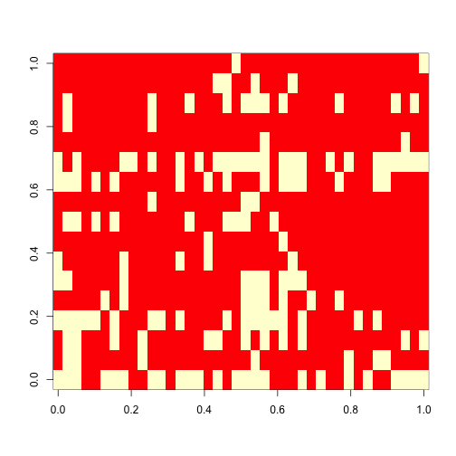

```r
image(dolphins)
```

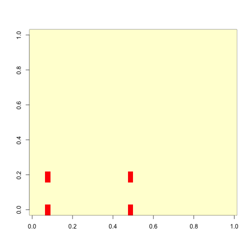

```r
image(dolphins == swap(dolphins))  #shows the code works
```

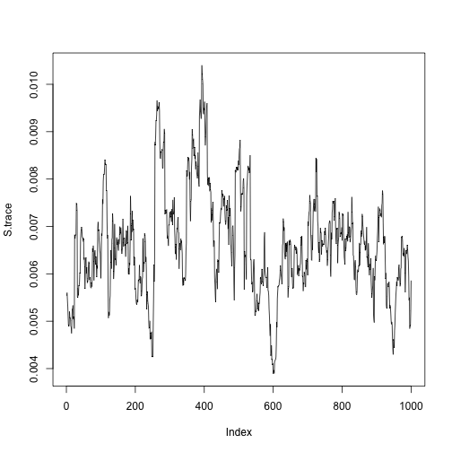

```r
m <- dolphins
D <- ncol(m)
n.swaps <- 1000
stack <- array(0, c(D, D, n.swaps))

for (i in 1:n.swaps) {
    stack[, , i] <- association.matrix(m)
    m <- swap(m)
}

e.matrix <- aaply(stack, c(1, 2), mean)
S.trace <- aaply(stack, 3, S, e.mat = e.matrix)
plot(S.trace, ty = "l")
```

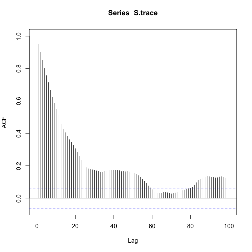

```r
acf(S.trace, 100)
```

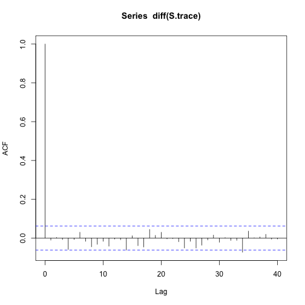

```r
acf(diff(S.trace), 40)
```

```r
o.matrix.observed <- association.matrix(dolphins)
S.observed <- S(o.matrix.observed, e.matrix)

S.observed
```

```
## [1] 0.005534
```

```r
burn.in <- 500
sum(S.trace[burn.in:n.swaps] >= S.observed)/(n.swaps - burn.in)
```

```
## [1] 0.856
```

## Readings:

Bejder, L., D. Fletcher, and S. BrÄger. 1998. A method for testing association patterns of social animals. Animal behaviour 56:719–725.  
Manly, B. F. 1995. A note on the analysis of species co-occurrences. Ecology:1109–1115.

## Additional Readings:

Combined with week #6 summary

# Week # 6 Summary

## Part 1: reviewing the dolphin permutation problem with swapping

We first reviewed our code that we were to have preprared for class that involved a functioning permutation script using with the dolphin data from Manly (1995). (See the end of week 5 for details on the problem). It seemed that everyone was on the same page in terms of having a working code in terms fo being able to swap the matrices.

Having a functioning swap and permute algorithm was critical to extend for MCMC chain convergence. For this week's summary, I will show what we did using Jon Borelli's code.

## Part 2: Markov Chain Monte Carlo overview and discussion

Heather provided a background on MCMC searches and chain convergence using slides written by Patrick Lim from Harvard ([http://www.people.fas.harvard.edu/~plam/teaching/methods/convergence/convergence_print.pdf](http://www.people.fas.harvard.edu/%7Eplam/teaching/methods/convergence/convergence_print.pdf)). THe main segway in this topic was from the dolphin project, in that an MCMC is searching association matrices based on the previous matrix swap. The point is that each next search is closely related to the search before it.

First I will summarize chain diagnostics from the lecture and then show the code and plots to diagnose convergence of an MCMC chain using our dolphin data.

Chain Diagnostics:  
*The “convergence” of the chain occurs when the sampling reaches a stable distribution.  
*If you would like to examine convergence diagnositics the “coda” package in R is good or there is a GUI program “tracer” in which you load traceplots into and can visualize.  
*Converence can be visualized with a trace plot. If the traceplot looks very jagged and does not have a solid median (“hairy caterpillar look”), then the sampling has not converged and has gotten stuck in parameter space when sampling. The “hairy caterpillar” look can be a good thing.  
*We also disscussed burn-in. There is a general acceptance of discarding a proportion of the initial sampling of parameter space.

*A fundamental question from this discussion: How many pair-switches do we need to feel like we sampled the space? For example: do we make 3 chains, each with length 400, and have a burn-in of 200 (keeping the last 200 of each chain) OR we have one chain of 1200 with 50% burn-in. Which is more informative?

## Part 3: Gelman-Rubin Multiple Sequence Diagnostic

We then proceeded to discuss the Gelman & Rubin Diagnostic which addresses the following concepts:  
*never use multiple chains because you want to sample different parts of space  
*want to send out multiple chains so they end up in the same place  
*how much variation is within each of these chains  
*G&B quantifies within chain variances (mean of within chain variances) and then like between chain variance (just like an anova!)

Steps (for each parameter) for GB: 1. Run m ≥ 2 chains of length 2n from overdispersed starting values.  
2. Discard the ﬁrst n draws in each chain.  
3. Calculate the within-chain and between-chain variance.  
4. Calculate the estimated variance of the parameter as a weighted sum of the within-chain and between-chain variance.  
5. Calculate the potential scale reduction factor.

The GB diagnostic can be run in R. The steps involve running out multiple chains of your simulation `mcmc()`, combinining your chains into a list `mcmc.list()`, and running the GB diagnostic on the list of chains `gelman.diag()`.

## Part 4: Implementation of plotting chain convergence of dolphin data

We want to visualize the MCMC run and view if there is a convergence on an interpretable distribution. We use Jon Borelli's code to compare short-chain and long-chain runs. We will then look at the plots and try to diagnose convergence.

```r
require(ggplot2)
require(RCurl)
options(RCurlOptions = list(cainfo = system.file("CurlSSL", "cacert.pem", package = "RCurl")))
url <- getURL("https://raw.githubusercontent.com/PermuteSeminar/PermuteSeminar-2014/master/Week-5/Dolphin+data.csv")
dolphins <- read.csv(text = url, row.names = 1, header = F)
colnames(dolphins) <- LETTERS[1:18]

# function for finding hwi of an association matrix
get_hwi <- function(mat) {
    hwi <- matrix(nrow = ncol(mat), ncol = ncol(mat))
    for (i in 1:ncol(mat)) {
        for (j in 1:ncol(mat)) {
            x <- sum(mat[, i] == 1 & mat[, j] == 1)
            ya <- sum(mat[, i] == 1 & mat[, j] == 0)
            yb <- sum(mat[, i] == 0 & mat[, j] == 1)
            hwi[i, j] <- x/(x + 0.5 * (ya + yb))
        }
    }
    return(hwi)
}

# this function permtes the matrix while keeping most structure intact
permutes <- function(mat, iter) {
    pattern1 <- matrix(c(0, 1, 1, 0), nrow = 2, ncol = 2)
    pattern2 <- matrix(c(1, 0, 0, 1), nrow = 2, ncol = 2)
    count <- 0
    mat.list <- list()
    hwi.list <- list()

    while (count < iter) {
        srow <- sample(1:nrow(mat), 2)
        scol <- sample(1:ncol(mat), 2)

        test <- mat[srow, scol]

        if (sum(test == pattern1) == 4) {
            count <- count + 1
            mat[srow, scol] <- pattern2
            mat.list[[count]] <- mat
            hwi.list[[count]] <- get_hwi(mat)
            next
        } else if (sum(test == pattern2) == 4) {
            count <- count + 1
            mat[srow, scol] <- pattern1
            mat.list[[count]] <- mat
            hwi.list[[count]] <- get_hwi(mat)
            next
        } else {
            next
        }
    }
    return(list(permuted.matrices = mat.list, hwi = hwi.list))
}

# short-chain
pdolph <- permutes(dolphins, iter = 100)
mat.ij <- t(sapply(pdolph$hwi, FUN = function(x) {
    x[which(lower.tri(x))]
}))
e.ij <- colMeans(mat.ij)


S <- c()
for (i in 1:nrow(mat.ij)) {
    top <- (mat.ij[i, ] - e.ij)^2
    bottom <- ncol(dolphins)^2
    S[i] <- sum(top/bottom)
}

# long chain
pdolph.long <- permutes(dolphins, iter = 1000)
long.mat.ij <- t(sapply(pdolph.long$hwi, FUN = function(x) {
    x[which(lower.tri(x))]
}))
e.ij <- colMeans(mat.ij)


S.2 <- c()
for (i in 1:nrow(long.mat.ij)) {
    top <- (long.mat.ij[i, ] - e.ij)^2
    bottom <- ncol(dolphins)^2
    S.2[i] <- sum(top/bottom)
}
```

Plots of the short-chain and long-chain runs.

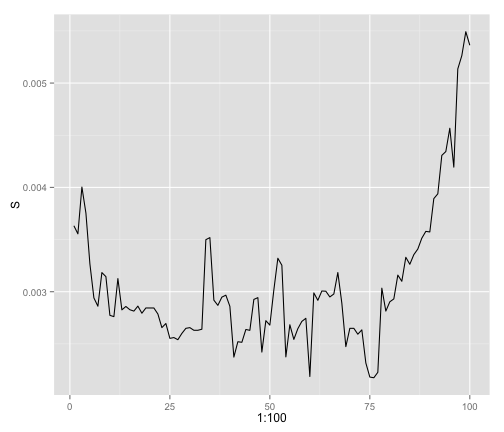

```r
ggplot(data.frame(S = S), aes(x = 1:100, y = S)) + geom_line()
```

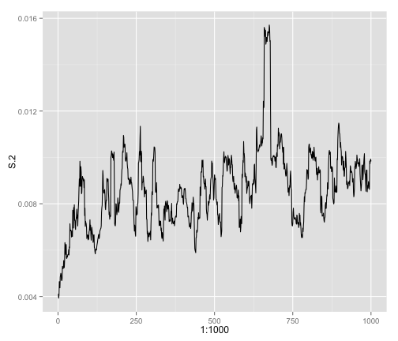

```r
ggplot(data.frame(S.2 = S.2), aes(x = 1:1000, y = S.2)) + geom_line()
```

## Assigned Readings:

Fridley, J. D., R. L. Brown, and J. F. Bruno. 2004. Null models of exotic invasion and scale-dependent patterns of native and exotic species richness. Ecology 85:3215–3222.

## Additional Reading:

Can use the MCMC to perform a multiple imputations, which can be used for estimating missing data. The following are two references that explain the R package and the second explains in more detail how the imputation works.

Osburn, J. Best practices in data cleaning. Ch. 6: Dealing with missing or incomplete data: debunking the myth of emptiness. SAGE Publications, INC., 2013:pp.104-138.

Buuren, S., Groothuis-Oudshoorn, K., Robitzsch, A., Vink, G., Doove, L., and Jolani, S. Package 'mice'. http://www.stefvanbuuren.nl , http://www.multiple-imputation.com, 2014.

Casella, G., and E. I. George. 1992. Explaining the Gibbs sampler. The American Statistician 46:167–174.

# Week #7 Summary

## What we did:

Read and discussed papers:

1. Besag J & Diggle PJ. (1977)
2. Lancaster J and Downes BJ. (2004)
3. Crowley PH. (1992)

## Monte Carlo vs. MCMC

we first clarified that the term Monte Carlo does not only refer to Markov Chain Monte Carlo (MCMC) methods. A Monte Carlo process is any random draw process. Markov Chain Monte Carlo methods, on the other hand, only relate to the preceeding time step. However, note that because the preceeding time step is always correlated with its corresponding previous time step, you could get very long correlation times. MCMC methods can sometimes be used to get likelihoods- when you don't know a likelihood function, but would like to sample from it, you might use MCMC. This is also relevant because this is in contrast to Bayesian methods, where you don't have a final distribution you can draw from.

## Besag and Diggle (1977)

The Besag and Diggle paper focused on general Monte Carlo methods. Monte Carlo processes can be very useful when full randomisation tests would be useful but are computationally difficult. They can also be used to test for spatial randomness in data. Here, the null would be complete spatial randomness, and you would use a test statistic to test this. For example, a test statistic proposed by Clarke and Evans (1954) uses nearest neighbor distances. A large sum of the nearest neighbor distances shows a tendency towards regularity, while a small sum shows clustering.

The next test using Monte Carlo methods is testing for pattern transference, for example, from small-scale migration to larger scales.

The third test was for space-time interaction. They give the example of disease outbreak, where to test if there is an outbreak, you need to see a large number of infected individuals in the SAME time step- you cannot collapse the data over time or over space and deduce an outbreak. Monte Carlo methods can help with this.

The fourth and last test is for patterns of scale, where you partition the area into blocks of different sizes and test for patterns over various combinations of blocks.

## Jacknife vs. Bootstrap. Crowley (1992)

The Crowley paper contrasted different randomisation methods (monte Carlo, jacknife, bootstrap; and their applications in Ecology and Evolution). We first discussed when one would use jacknife over bootstrap methods. Jacknife only gives you standard errors, unlike bootstrap which also gives you percentile values. So the bootstrap gives you more information than the jacknife does. The bootstrap also simulates a rerun of your experiment, while the jacknife is a more independent test.

However, you might want to use jacknife rather than bootstrap if you are running species distribution models (SDMs). When you bootstrap in SDMs, you might be assuming that your environmental variables are coming from a bigger set of variables, in which case you are testing the effect of your variables as opposed to that bigger set. So doesn't make as much sense as doing a jacknife- where you are testing the effect of any one variable at a time on the distribution.

## Reviewing some concepts

We then reviewed a few concepts (just to be clear!): A parametric bootstrap is when you fit your data to a distribution and sample from the distribution rather than from the original data (which is a non-parametric bootstrap, of course). We defined power- the probability that you will correctly reject the null hypothesis. This is also the opposite of a Type II error. Non-parametric methods are rank-based methods, like Wilcoxon's signed-rank test. These methods have low power. Parametric tests, on the other hand, have high power given that their assumptions are met.

When you do randomisation tests, you get high power (which also means a high false alarm rate), high rate of Type I errors, and low rate of type II errors. If you violate the assumptions of the t-test, your power increases, but you no longer know what your level of sginificance is. This is linked to why experimental design in frequentist statistics is subjective- depending on the design of your experiment, your thresholds of significance change. Thus, you need to have considerable transparency when you are publishing significance levels after performing frequentist statistics.

## Spatial autocorrelation. Lancaster and Downes (2004)

We then continued by discussing the Lancaster and Downes (2004) paper and parts of the Crowley (1992) paper in parallel, as their themes overlapped. The Lancaster and Downes paper addressed spatial point pattern analysis, given patchiness vs regularity of resource availability.

The first problem is that of autocorrelation. It does not allow you to easily write down likelihoods, as they would be functions of other likelihoods. Here arises the difference between independent variables, and conditionally independent variables. In this case, the spatial structure of covariates and responses is important. You only have to account for spatial autocorrelation when you create a joint probability of all likelihoods- when there is conditional independence. For example:

P(brown hair AND blue eyes) = P(brown hair)*P(blue eyes)

is true only if the two terms on the right are independent. Otherwise, you don't know the interaction term where they intersect. In these situations of conditional probability, randomisation methods come in handy. In our partcular interest here- with spatial autocorrelation- you would use MCMC methods, because even though you can't write down the likelihood function, you can sample from the likelihood distribution. The Knox test is one technique, where you hold space constant and permute time, and the other way around. This technique is not used much, because specifying a cut-off is difficult.

We then moved to the exciting issue of edge correction. Drawing an amorphous form on the board, which was then christened a lake, we discussed different ways of correcting for sampling from edges. To determine how resource availability and species presence are related, for instance in stated lake, we might sample a point at random from within the lake. We would then draw a circle of radius 't' with that ,point at the center, and count how many points in total that circle encompasses. The Lancaster and Downes paper focuses on how you can correct for the inevitable bias of sampling points near the edge of this lake- the circles around those points would encompass much fewer points than those at the center, simply because half the circle would fall outside the habitat edge.

Using this formula, you can describe a cumulative frequency distribution of all point-to-point distances: \[ K(t) = n^{-2}A\sum_{i=i}^{n} \sum_{j\neq i}^{n}w_{ij}I_{t}(u_{ij}) \]

This K(t) function is often represented as a linearised L function: \[ L(t) = \sqrt{K(t)/\pi} - t \]

So, if you are dealing with datasets with complex edges that you want to compensate for, these are some possible tools to use. Note that it is not always prudent to do edge corrections. In some cases, it does not change the results at all, in others it in fact confounds the results. Thus it should only be performed when there is a biological/ecological basis to use edge corrections.

## Assigned Papers:

Besag J & Diggle PJ. 1977. Simple Monte Carlo Tests for Spatial Pattern. Journal of the Royal Statistical Society. Series C (Applied Statistics), Vol. 26, No. 3, pp. 327-333.  
Lancaster J and Downes BJ. 2004. Spatial Point Pattern Analysis of Available and Exploited Resources. Ecography, Vol. 27, No. 1, pp. 94-102.

Crowley PH. 1992. Resampling methods for computation-intensive data analysis in ecology and evolution. Annual Review of Ecology, Evolution and Systematics, 23:405-47.

## Additional Papers:

Refer to summary # 8

# Week #8 Summary

## Loosmore and Ford (2006)

They suggest a goodness-of-fit test to test for differences between observed and null models by reducing the patterns to a single statistic, and comparing the rank of the observed statistic to the simulations. This reduces the number of caparisons being made and provides the correct type 1 error rate. They also provide a method to calculate uncertainty in the p value estimated.

## Examples of Spatial Stats Using Seal Data

```r
require(spatstat)
```

```r
library(igraph)
require(ggplot2)
require(gridExtra)
require(rgdal)
require(RCurl)
```

## Loading the data

```r
url.avian <- getURL("https://raw.githubusercontent.com/PermuteSeminar/PermuteSeminar-2014/master/Weekly%20Summaries/Week%208%20Summary/data/AVIA_table.txt")
url.paulet <- getURL("https://raw.githubusercontent.com/PermuteSeminar/PermuteSeminar-2014/master/Weekly%20Summaries/Week%208%20Summary/data/Paulet_table.txt")
avian <- read.table(text = url.avian, sep = ",", col.names = c("lat", "lon"))
paulet <- read.table(text = url.paulet, sep = ",", col.names = c("lat", "lon"))
```

The data points are in a geographic coordinate system (lat,lon) with a unit of decimal degrees. To work with meters these points need to be in a projected coordinate system. This can be done using `spTransform` from the package `rgdal`, requiring the geographic coordinate system, and a suitable projected system. Polar Stereographic is appropriate for these latitudes.

```r
coordinates(avian) <- ~lon + lat
proj4string(avian) <- CRS("+proj=longlat +ellps=WGS84")
avian <- as.data.frame(spTransform(avian, CRS("+proj=stere  +units=m +ellps=WGS84")))

coordinates(paulet) <- ~lon + lat
proj4string(paulet) <- CRS("+proj=longlat +ellps=WGS84")
paulet <- as.data.frame(spTransform(paulet, CRS("+proj=stere  +units=m +ellps=WGS84")))
```

## Creating a point pattern object with `spatstat`

`spatstat` has a function `ppp()` which takes a vector of x coordinates, a vector of y coordinates, and a window which defines the boundaries of the point process. The function returns an object of class `ppp` which can be analysed using spatial statistics in `spatstat`. To create the window we took a convex hull of the points, either using..

- `chull {chull}`
- `convex.hull {igraph}`
- `convexhull {spatstat}`

```r
avianBoundary = convex.hull(as.matrix(avian))$rescoords
avian.ppp = ppp(avian$lon, avian$lat, poly = list(x = rev(avianBoundary[, 1]),
    y = rev(avianBoundary[, 2])))
```

```r
pauletBoundary = convex.hull(as.matrix(paulet))$rescoords
paulet.ppp = ppp(paulet$lon, paulet$lat, poly = list(x = rev(pauletBoundary[,
    1]), y = rev(pauletBoundary[, 2])))
```

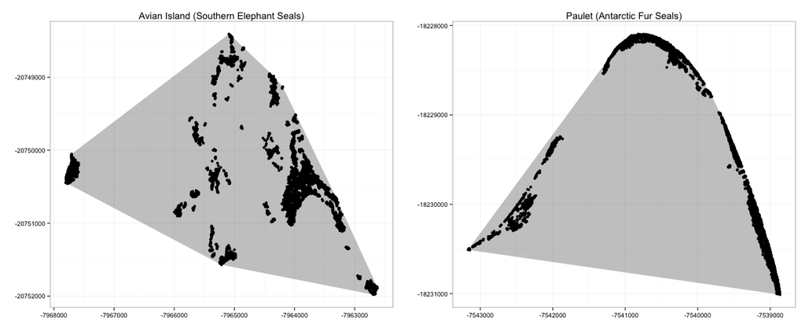

However this convex hull includes a lot of space in which there are no seals, probably due to the terrain rather than a second order point interaction. In this case simulating a Poisson point process over the whole window would be inappropriate, as we know that the intensity of the process varies over the window. This leads to a problem called 'virtual clustering' where points appear to be under-dispersed in statistics such as Ripleys K, while the points may actually be distributed completely randomly within the available space. A more appropriate null would be to simulate a PPP in the region that is actually available to seals.

> see 'Handbook of Spatial Point-Pattern Analysis in Ecology'. Wiegand, Thorsten, and Kirk A. Moloney. CRC Press, 2013. pg 121

This was dealt with by sub-setting the data into regions where the intensity appeared to be constant, either through selecting a smaller window, or by selecting a subset of the points and fitting a convex hull to those points.

```r
avianSub <- avian[which(avian$lon < -7967000), ]
avianSubBoundary = as.data.frame(convex.hull(as.matrix(avianSub))$rescoords)


avianSub.ppp = ppp(avianSub$lon, avianSub$lat, poly = list(x = rev(avianSubBoundary[,
    1]), y = rev(avianSubBoundary[, 2])))
```

```r
pauletSub <- paulet[which(paulet$lat < -18230000 & paulet$lon > -7540000), ]
pauletSubBoundary = as.data.frame(convex.hull(as.matrix(pauletSub))$rescoords)


pauletSub.ppp = ppp(pauletSub$lon, pauletSub$lat, poly = list(x = rev(pauletSubBoundary[,
    1]), y = rev(pauletSubBoundary[, 2])))
```

[figure not shown]

There are several other options for dealing with heterogeneity, such as:

- **Heterogeneous Poisson Process with Nonparametric Intensity Estimate** - Non-parametric kernel estimates of the intensity function are used in reconstructing the point process acting as a null model. Deviations from the statistics expected under the non-stationary PPP then indicate interactions between points (at distances less than the bandwidth of the kernel)
- **Heterogeneous Poisson Process with Parametric Intensity Estimate** - The heterogeneous Poisson process can also be characterized using parametrically estimated intensity functions. This requires additional environmental covariates and if misspecified can result apparent departures from CSR at larger distances. Estimating the parameters of the intensity function is the basis of habitat suitability modelling.

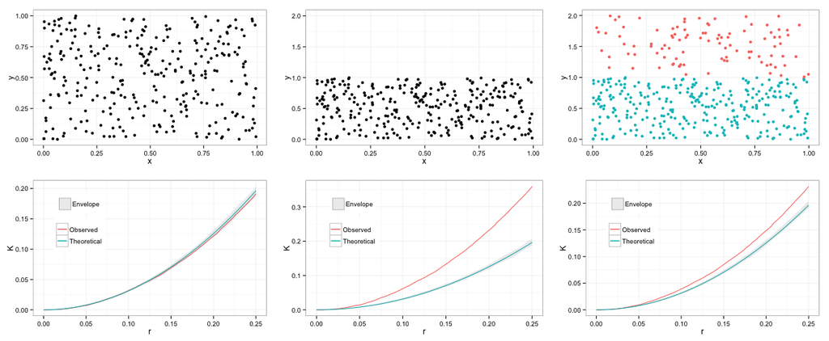

> A demonstration of virtual clustering. In the first example a Poisson point process has been generate with intensity 300 (300 points within 1x1 area). Ripley's K for this plot closely matches the expect under CSR and is well within the limits of the envelope created by calculating Ripleys K from 99 simulated Poisson Point Processes (\( \lambda=300 \)) within the 1x1 window. In the second example the same points are used but the window is extended beyond the limits of the PPP. When Ripleys K is caluclated there appears to be clustering at all scales, when actually there is no interaction between points in the region where the PPP operates. In the third example the points are generated from two poisson point process (blue intensity = 300, red intensity = 100). Ripleys K again show clustering at all scales, despite the points being randomly distributed.

## Calculating Spatial Statistics with `spatstat`

A range of spatial statistics are available in `spatstat`. To analyse the seal data we used second-order statistics which deal with distances between points. First-order statistics deal with the intensity of points in a point process. The statistics that were used were:

- `Kest()` - Estimates Ripley's reduced second moment function K® from a point pattern in a window of arbitrary shape.
- `Gest()` - Estimates the nearest neighbor distance distribution function G® from a point pattern in a window of arbitrary shape.

These statistics are calculated from all points and are expected to represent the typical point, however we can get an estimate of the variability between points, and use this to construct confidence intervals for our statistic.

- `varblock` - estimates the variance of any summary statistic (such as the K-function) by spatial subdivision of a single point pattern data-set.

These functions can be used to calculate the required statistic for an observed point pattern, however we often want to test if the stats generated from the observed are different from those expected from a null point process, such as CSR. The `envelope()` function in the `spatstat` package can be used to create a set of simulated point processes within a window,and calculate any spatial statistic for both the simulated processes and the observed process. These can then be plotted to examine departures from the null point process, but remember the issue of multiple comparisons!

- `envelope()` - Computes simulation envelopes of a summary function.

`spatstat` also has a function to perform the GoF test discussed in the Loosemore and Ford (2006) paper.

- `dclf.test()` - Perform the Diggle (1986) / Cressie (1991) / Loosmore and Ford (2006) test or the Maximum Absolute Deviation test for a spatial point pattern.

**Avian Island - Southern Elephant Seals**

```r
env.K = envelope(verbose = F, avianSub.ppp, fun = Kest, nsim = 199)
env.G = envelope(verbose = F, avianSub.ppp, fun = Gest, nsim = 199)
```

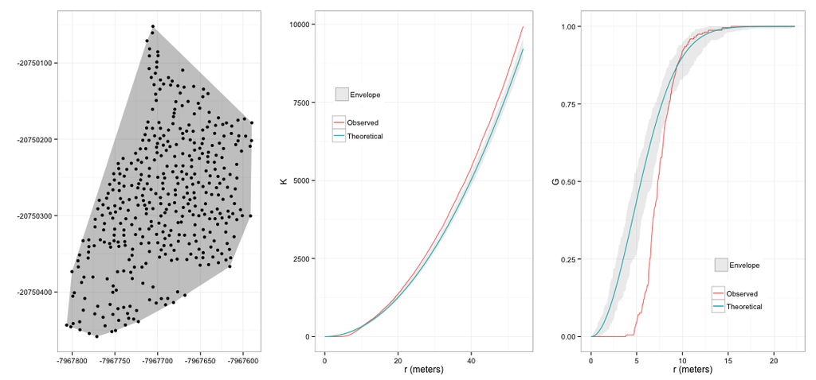

**Paulet - Antarctic Fur Seals**

```r
env.K = envelope(verbose = F, pauletSub.ppp, fun = Kest, nsim = 199)
env.G = envelope(verbose = F, pauletSub.ppp, fun = Gest, nsim = 199)
```

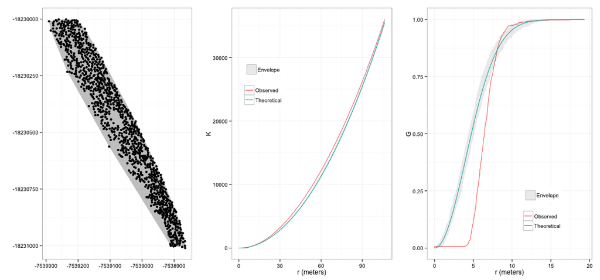

Both point patterns seem to show over-dispersion at short ranges, with no nearest neighbor distances less than ~4m. This would be expected if there were repulsion between the points. There appears to be clustering at larger spatial scales, which is likely due to the inhomogenous point process rather than interaction between the points.

## Distributions of k nearest neighbor distances

As we are actually interested in the differences between the two point patterns rather than between those point patterns and CSR, a comparison of the distributions of neighbor distances was suggested.

> Code from Sams script

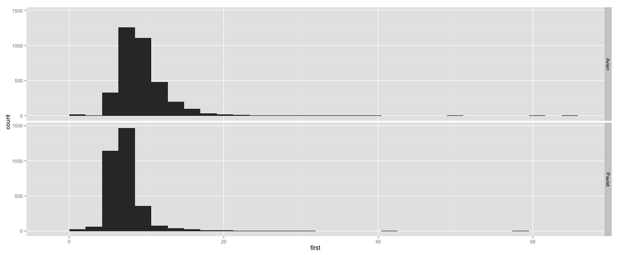

```r
nearest.distances <- data.frame(Island = c(rep("Avian", avian.ppp$n), rep("Paulet",
    paulet.ppp$n)), first = c(nndist(avian.ppp), nndist(paulet.ppp)), second = c(nndist(avian.ppp,
    k = 2), nndist(paulet.ppp, k = 2)), third = c(nndist(avian.ppp, k = 3),
    nndist(paulet.ppp, k = 3)))

ggplot(nearest.distances, aes(x = first)) + geom_histogram() + facet_grid(Island ~
    .)
```

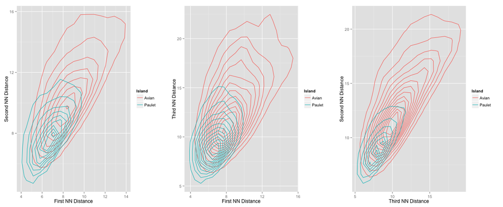

```r
p1 = ggplot(nearest.distances, aes(x = first, y = second, color = Island)) +
    geom_density2d() + labs(y = "Second NN Distance", x = "First NN Distance")
p2 = ggplot(nearest.distances, aes(x = first, y = third, color = Island)) +
    geom_density2d() + labs(y = "Third NN Distance", x = "First NN Distance")
p3 = ggplot(nearest.distances, aes(x = second, y = third, color = Island)) +
    geom_density2d() + labs(y = "Second NN Distance", x = "Third NN Distance")
grid.arrange(p1, p2, p3, ncol = 3)
```

## Assigned Readings:

Loosmore, N. B., and E. D. Ford. 2006. Statistical inference using the G or K point pattern spatial statistics. Ecology 87:1925–1931.

## Additional References:

Reference deals with spatial analysis of other groups of organisms using various techniques.

Cole, R. G., and C. Syms. 1999. Using spatial pattern analysis to distinguish causes of mortality: an example from kelp in north‐eastern New Zealand. Journal of Ecology 87:963–972.

Svoboda, P., J. Kulichová, and J. Št’astný. 2013. Spatial and temporal community structure of desmids on a small spatial scale. Hydrobiologia 722:291–303.

Fahrig, L., and J. Paloheimo. 1988. Effect of spatial arrangement of habitat patches on local population size. Ecology 69:468–475.

# Week #9 Summary

# Null Models

The first issue is to clarify the definition of a null model. That is, what constitutes a truly null biological model? A null model needs to provide the simplest possible answer to a question. Ideally, a null model requires no knowledge of a system, and should include no process of biological relevance. it is “the most boring explanation possible that could be observed”.  
However, null models are devised to test specific aspects of biology, and as such are drawn with respect to parameters (for example, one could decide to design a null model with respect to species richness, and therefore should keep species richness constant.) The trick is to understad what must be kept constant when bootstraping to test aginst a null model (for example, if we consider our dolphin dataset (weeks 5-6), part of the issue was deciding if we wanted to keep the rows, colums or both constant). Those could be considered biological factors that go into the model. Then, a null model is one that would produce “biological randomness”.  
In short, we want to determine how much biology there is in a system: if we consider null models to have no biology, any deviation from such a model will be a clue that there is in fact a biologically relevant process at work. If, for example, we want to look at species distribution, we need to first identify that there is a deviation from randomness. Only then can we identify areas of large deviance and study them in more details.  
We examined a null model described in Colwell & Lees (2000): the Mid Domain Effect (MDE)  
The MDE is a purely geometric model that predicts that the greatest richness of species will be found in the middle of given 2-D areas (as given by such gradients as latitude or elevation along a mountain flank)

# What we did:

We wanted to test two datasets against the MDE null model.

```r
require("RCurl")
require("reshape2")

url.humming <- getURL("https://raw.githubusercontent.com/PermuteSeminar/PermuteSeminar-2014/master/Null%20models/Hummingbirds.csv")
url.hylids <- getURL("https://raw.githubusercontent.com/PermuteSeminar/PermuteSeminar-2014/master/Null%20models/Hylids.csv")
humming <- read.csv(text = url.humming, header = T, row.names = 1)
hylids <- read.csv(text = url.hylids, header = T, row.names = 1)

elev.hu <- as.numeric(gsub("Elev_", "", rownames(humming)))
elev.hy <- as.numeric(gsub("Elev_", "", rownames(hylids)))
```

The two datasets were presence/absence matrices for Hylids and Hummingbirds for given elevation on a mountain flank. Here, it was decided to keep the range of each species constant, as it is a primary predictor of the MDE.

Simply put, we wanted to randomize the range of each species to obtain a random distribution of species richness at each elevation, to compare the actual data with.

A good idea was to use the function 'rle', which returns the number of times a certain value is repeated consecutively (like 0s and 1s in our data set.) However, There are the possibilities that rle returns different vectors if ranges are located at the edge of the elevation gradient, so this would complicate the code by introducing several if conditions, as seen in Heather's code:

```r
matrix.store <- list()
maxit <- 500
colsum.matrix <- matrix(NA, ncol = maxit, nrow = 25)
for (i in 1:maxit) {
    #open fori
    matrix.ran <- c()
    for (j in 1:ncol(humming)) {
        #open forj
        temp <- rle(humming[, j])
        if (length(temp$lengths) == 3)
            {
                #open if: The following 3 if conditions set the different outcomes of the rle function
                temp
                shift <- sample(seq(-temp$lengths[1], temp$lengths[3]), size = 1)
                temp$lengths[1] <- temp$lengths[1] + shift
                temp$lengths[3] <- temp$lengths[3] - shift
                matrix.ran <- cbind(matrix.ran, inverse.rle(temp))
            }  #close if
        if ((length(temp$lengths) == 2) & (temp$values[1] == 0))
            {
                #open if
                temp
                shift <- sample(seq(0, temp$lengths[1]), size = 1)
                temp$lengths[1] <- temp$lengths[1] - shift
                temp$lengths[3] <- shift
                temp$values[1] <- 0
                temp$values[2] <- 1
                temp$values[3] <- 0
                matrix.ran <- cbind(matrix.ran, inverse.rle(temp))
            }  #close if
        if ((length(temp$lengths) == 2) & (temp$values[1] == 1))
            {
                #open if
                temp
                shift <- sample(seq(0, temp$lengths[2]), size = 1)
                range.length <- temp$length[1]
                c <- temp$lengths[2] - shift
                temp$lengths[1] <- shift
                temp$lengths[2] <- range.length
                temp$lengths[3] <- c
                temp$values[1] <- 0
                temp$values[2] <- 1
                temp$values[3] <- 0
                matrix.ran <- cbind(matrix.ran, c(rep(0, times = shift), rep(1,
                  times = range.length), rep(0, times = c)))
            }  #close if
    }  #close forj
    matrix.store[[i]] <- matrix.ran
    colsum.matrix[, i] <- apply(matrix.store[[i]], 1, sum)
}  #close fori
```

Jon decided to bypass the rle issue, and instead used summing and randomly assinging a single starting point for the ranges, and setting the following n-1 elevations to have a presence record for a species with range n.

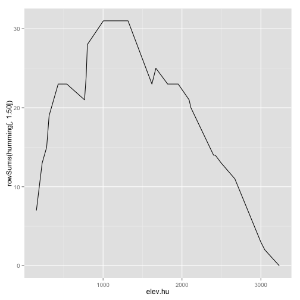

```r
require(ggplot2)
ggplot(humming, aes(x = elev.hu, y = rowSums(humming[, 1:50]))) + geom_path()
```

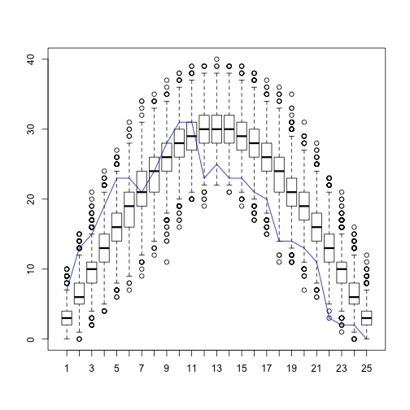

```r
## Function to permute ranges
permute_range <- function(data) {
    #open function
    elev <- as.numeric(gsub("Elev_", "", rownames(data)))  # replaces the first colums of the dataset with their actual value
    # Calculate range sizes for each species
    rangeSize <- colSums(data)  #creates a vector for each species indicating the size of their range
    # Create matrix to fill with new ranges
    new.ranges <- matrix(nrow = length(elev), ncol = length(rangeSize))  #creates an empty matrix to recieve the randomized data
    # For loop to shift range for each species
    for (i in 1:length(rangeSize)) {
        #open for
        perm.mat <- matrix(0, nrow = length(elev), ncol = 1)  #creates a matrix with 1 column full of 0
        upperlim <- length(elev) - rangeSize[i]  #no clue creates a value that substracts the range size for spp i from the number of elevation points
        # this should be the number of 0s in the random data set
        start <- sample(c(1:upperlim), 1)  #will sample a random number between 1 an the number of 0s in the dataset
        perm.mat[start:(start + rangeSize[i]), ] <- 1  #gives that random number and the range size for spp i and sets it to 1
        new.ranges[, i] <- perm.mat  #Huzzah
    }  # close for
    return(list(ranges = new.ranges, tot.num = rowSums(new.ranges)))
}  #close function

## Function to wrap the permute function across any number of permutations
wrapper <- function(n, data) {
    p.ranges <- matrix(nrow = n, ncol = nrow(data))
    for (i in 1:n) {
        numSpec <- permute_range(data)$tot.num
        p.ranges[i, ] <- numSpec
    }
    return(p.ranges)
}

test <- wrapper(5000, humming)
boxplot(test)
points(1:25, rowSums(humming), typ = "l", col = "blue")
```

```r
# get quantiles
quant.hu <- apply(test, 2, quantile, probs = c(0.025, 0.975))
q.dat <- melt(data.frame(t(quant.hu)))
```

```
## Using  as id variables
```

```r
q.dat2 <- cbind(q.dat, num = rep(1:25, 2))

## Make it pretty with ggplot2
colnames(test) <- elev.hu
mtest <- melt(test, id.vars = colnames(test))
g <- ggplot(mtest, aes(x = factor(Var2), y = value)) + geom_boxplot()
g <- g + geom_path(data = humming, aes(x = 1:25, y = rowSums(humming[, 1:50])),
    col = "blue")
g <- g + geom_point(data = humming, aes(x = 1:25, y = rowSums(humming[, 1:50])),
    col = "blue", size = 3)
g + geom_line(data = q.dat2, aes(x = num, y = value, col = variable))
```

```
## Error: object 'Var2' not found
```

For a reason I havent been able to recognize (but that probably has to do with the way the ranges were assigned to the randomized matrix), Jon's richness values are shifted upwards by a small number (less than 5).

## Assigned Reading:

Colwell, R. K. and D. C. Lees. 2000. The mid-domain effect: geometric constraints on the geography of species richness. Trend in Ecology and Evolution 15(2): 70-76.

Jetz, W., C. Rahbek and R. K. Colwell. 2004. The coincidence of rarity and richness and the potential signature of history in centres of endemism. Ecology Letters 7: 1180-1191.

# Summary Week 10

Most studies correlating the native to exotic species richness have found negative and positive correlations at small and large scales, respectively. Researchers have proposed that at smaller scales native species competitively exclude exotic species. Conversely, at larger scales researchers have proposed that environmental effects mask the negative effects of native species richness on exotics, leading to a positive correlation.

Fridley et al. (2004) proposed that the spatial relationships could not be due to biological interactions between native and exotics. Instead, the spatial correlation may be due to chance. As such, they tested two datasets relating native to exotic species against a null distribution, and found that the null distrubution fit both datasets well. As such, they concluded that native species may have no biological influence on exotic species, and the patterns seen at various spatial scales may be due primarily to stastical artifacts (i.e chance).

## Objective 1:

```r
###### Defining all variables

reps <- 100  #Number of replicates for each sample size

samps <- c(5, 10, 20, 50, 100, 800)  #sample sizes, in number of represented individuals

pool.range <- c(20, 100)

NEprop <- c(0.75, 0.15, 0.1)  #proportion of, respectively, natives, exotics, and bare spaces in pool (totals to 1)

tot.pool <- round(runif(reps, pool.range[1], pool.range[2]))  #randomly generate [reps]-length vector of total pool sizes

# make a output matrix to fill all the different simulations (why we have
# a third dimension, so that it does not replace the earlier matrix)

output <- array(0, dim = c(2, length(samps), reps))

# loop to simulate the matrixes

for (j in 1:reps) {

    # determine pool composition for replicate

    natives <- paste("N", c(1:round(NEprop[1] * tot.pool[j])))  #list of native species

    exotics <- paste("E", c(1:round(NEprop[2] * tot.pool[j])))  #list of exotic species

    zeros <- paste("Z", c(1:round(NEprop[3] * tot.pool[j])))
    # list of free spaces

    allspp <- c(natives, exotics, zeros)
    # list of all species and blanks

    # randomly construct simulated community

    ind.vec <- floor(rlnorm(length(allspp), 8, 1))
    # create list of abundances for each species, from lognormal abundance
    # distribution

    comm <- rep(allspp[1], ind.vec[1])
    # populate first species in pool with its associated abundance

    for (i in 2:length(allspp)) {
        # loop over all remaining species

        comm <- c(comm, rep(allspp[i], ind.vec[i]))
        # populate remaining species with associated abundances

    }  #close loop

    for (i in 1:length(samps)) {
        # Loop for different sample sizes

        rs <- sample(comm, samps[i])  #draw randomly from community pool of individuals with given sample size

        output[1, i, j] <- length(unique(rs[is.element(rs, natives)]))  #total richness of natives in the sample

        output[2, i, j] <- length(unique(rs[is.element(rs, exotics)]))  #total richness of exotics in the sample

    }
}  #end sample size loop
```

Recreate Figure 1 from Fridley et al. (2004)

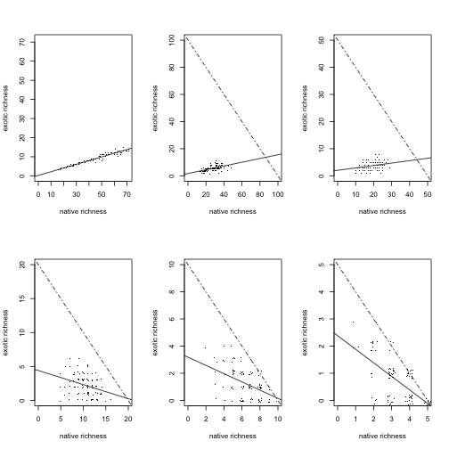

```r
par(mfrow = c(2, 3))
# Graph N=800
plot(output[1, 6, ], output[2, 6, ], pch = ".", xlab = "native richness", ylab = "exotic richness",
    xlim = c(0, max(output[1:2, 6, ])), ylim = c(0, max(output[1:2, 6, ])))

abline(lsfit(output[1, 6, ], output[2, 6, ]))
# least-squares regression line

# Graph N=100
plot(output[1, 5, ], output[2, 5, ], pch = ".", xlab = "native richness", ylab = "exotic richness",
    xlim = c(0, samps[5]), ylim = c(0, samps[5]))

abline(lsfit(output[1, 5, ], output[2, 5, ]))  #least-squares regression line

abline(samps[5], -1, lty = 4)
# data constraint envelope, based on sample size

# Graph N=50
plot(output[1, 4, ], output[2, 4, ], pch = ".", xlab = "native richness", ylab = "exotic richness",
    xlim = c(0, samps[4]), ylim = c(0, samps[4]))

abline(lsfit(output[1, 4, ], output[2, 4, ]))
# least-squares regression line

abline(samps[4], -1, lty = 4)
# data constraint envelope, based on sample size

# Graph N=20
plot(jitter(output[1, 3, ]), jitter(output[2, 3, ]), pch = ".", xlab = "native richness",
    ylab = "exotic richness", xlim = c(0, samps[3]), ylim = c(0, samps[3]))

abline(lsfit(output[1, 3, ], output[2, 3, ]))
# least-squares regression line

abline(samps[3], -1, lty = 4)
# data constraint envelope, based on sample size

# Graph N=10
plot(jitter(output[1, 2, ]), jitter(output[2, 2, ]), pch = ".", xlab = "native richness",
    ylab = "exotic richness", xlim = c(0, samps[2]), ylim = c(0, samps[2]))

abline(lsfit(output[1, 2, ], output[2, 2, ]))
# least-squares regression line

abline(samps[2], -1, lty = 4)
# data constraint envelope, based on sample size

# Graph N=5
plot(jitter(output[1, 1, ]), jitter(output[2, 1, ]), pch = ".", xlab = "native richness",
    ylab = "exotic richness", xlim = c(0, samps[1]), ylim = c(0, samps[1]))

abline(lsfit(output[1, 1, ], output[2, 1, ]))
# least-squares regression line and have a data constraint envelope, based
# on sample size
abline(samps[1], -1, lty = 4)
```